# Assignment 3: Sentiment Classification Reflection

### **1. Training Dynamics**

*Focus on your MLP and LSTM implementations* - Did your models show signs of overfitting or underfitting? What architectural or training changes could address this?

Yes. The MLP showed overfitting in the final training epochs, as validation accuracy and macro F1 decreased while training performance remained high. Overfitting could be reduced by applying dropout, L2 weight decay and early stopping.

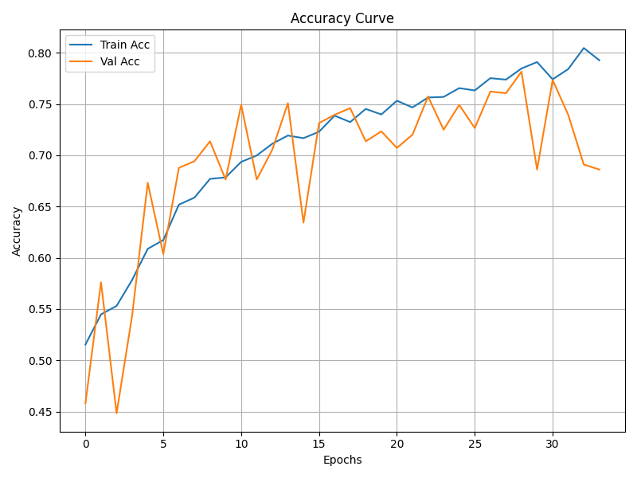

- How did using class weights affect training stability and final performance?

Using class weights can improve macro F1 score by reducing bias toward the majority class and improving minority class performance, leading to better overall and more balanced final performance.

### **2. Model Performance and Error Analysis**

*Focus on your MLP and LSTM implementations* - Which of your two models generalized better to the test set? Provide evidence from your metrics.

The LSTM model generalized better to the test set. First, The test accuracy of LSTM achieves 76.2%, whereas the MLP achieves only 73.7%. Second, the test macro F1 score of LSTM achieves 73.5%, whereas the MLP achieves only 70.4%.

**LSTM:**

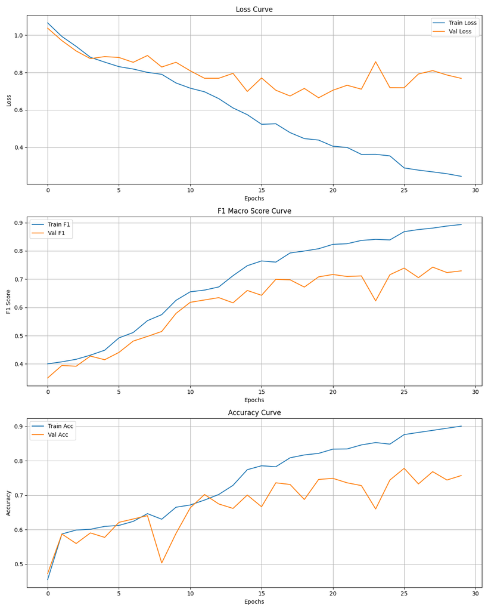

**MLP:**

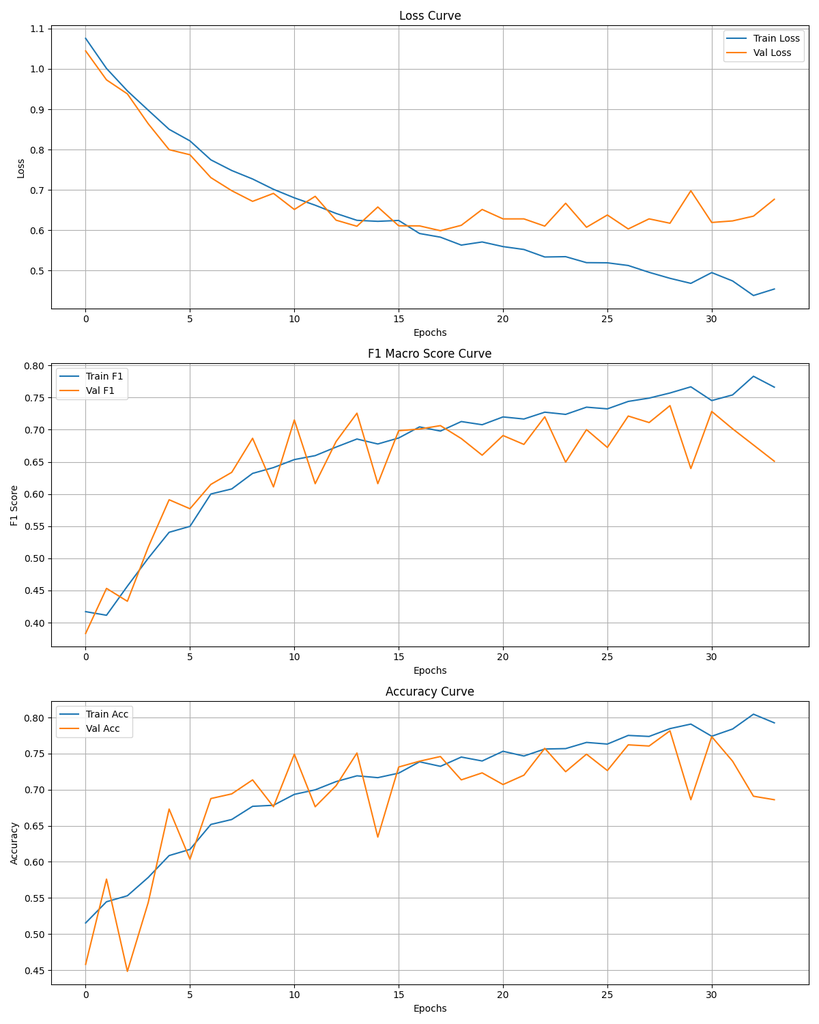

- Which sentiment class was most frequently misclassified? Propose reasons for this pattern.

The Neutral class was the most frequently misclassified in terms of absolute numbers.

LSTM: 92 Neutral samples were misclassified (69 as Positive, 23 as Negative).

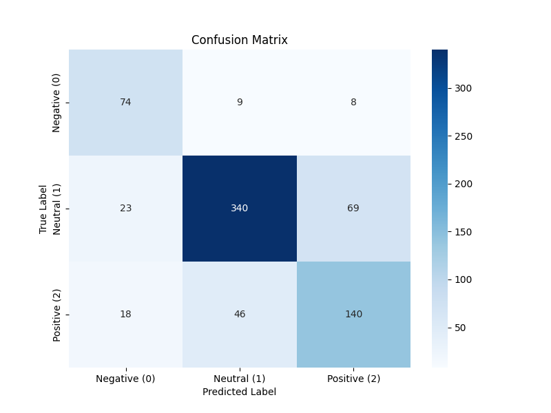

MLP: 100 Neutral samples were misclassified (74 as Positive, 26 as Negative).

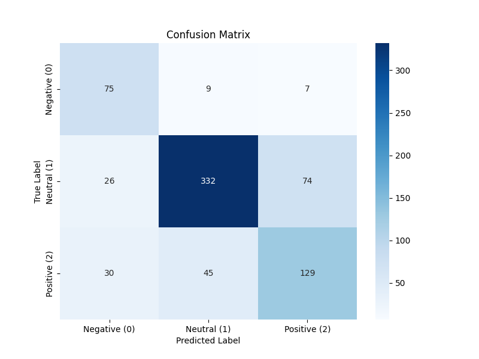

On one hand, the Neutral class represents the majority of the dataset (432 samples vs. 204 Positive and 91 Negative). The sheer volume of Neutral examples naturally leads to a higher total count of errors. On the other hand, The boundary between “Neutral” and “Positive” is often subjective.

### **3. Cross-Model Comparison**

*Compare all six models: MLP, RNN, LSTM, GRU, BERT, GPT* - How did mean-pooled FastText embeddings limit the MLP compared to sequence-based models? - Mean pooling compresses each sentence into a single static vector, which removes word order and local contextual information. As a result, the MLP can only rely on averaged semantic content and cannot effectively capture negation, modifiers, or word interactions, limiting its expressive power. - What advantage did the LSTM’s sequential processing provide over the MLP?

The LSTM models sentences as sequences, allowing it to capture word order, contextual dependencies, and long-range interactions. This enables the model to better handle negation, sentiment shifts, and temporal dependencies, leading to improved performance over the MLP on sentiment classification tasks. - Did fine-tuned LLMs (BERT/GPT) outperform classical baselines? Explain the performance gap in terms of pretraining and contextual representations.

Yes. Large-scale pretraining on diverse corpora provides strong linguistic and domain knowledge. Contextualized token representations adapt word meanings based on surrounding context. - Rank all six models by test performance. What architectural or representational factors explain the ranking?

The models generally rank as follows from highest to lowest performance: BERT, GPT, LSTM, GRU, RNN, MLP

Transformers (BERT and GPT) use self-attention to relate every token in a sequence to every other token simultaneously. This allows them to capture long-range dependencies without the “forgetting” issues of RNNs.

Gate mechanism (Used in LSTM and GRU) solves the vanishing gradient problem, allowing them to remember information from the beginning of a sentence much better than a standard RNN.

## AI Use Disclosure (Required)

If you used any AI-enabled tools (e.g., ChatGPT, GitHub Copilot, Claude, or other LLM assistants) while working on this assignment, you must disclose that use here. The goal is transparency-not punishment.

In your disclosure, briefly include: - **Tool(s) used:** (name + version if known) - **How you used them:** (e.g., concept explanation, debugging, drafting code, rewriting text) - **What you verified yourself:** (e.g., reran the notebook, checked outputs/plots, checked shapes, read documentation) - **What you did *not* use AI for (if applicable):** (optional)

You are responsible for the correctness of your submission, even if AI suggested code or explanations.

#### Write your disclosure here.

- **Tool(s) used:** ChatGPT
- **How you used them:** debugging, drafting code, rewriting text
- **What you verified yourself:** checked outputs/plots, checked shapes, writed code, described the conclusion
- **What you did *not* use AI for (if applicable):** (optional)